Skip to main content

# Too little, too much water

Drought and heavy rain in Europe and Germany

Author

Noemi Ambrosi

*A story created @ Visualising Climate 2026, Bologna*

Heat is the clearest signal in the E3CI, but water tells a more complicated story: months of drought and months of extreme rain, sometimes in the same country and in the same years. We follow both, from Europe down to Germany.

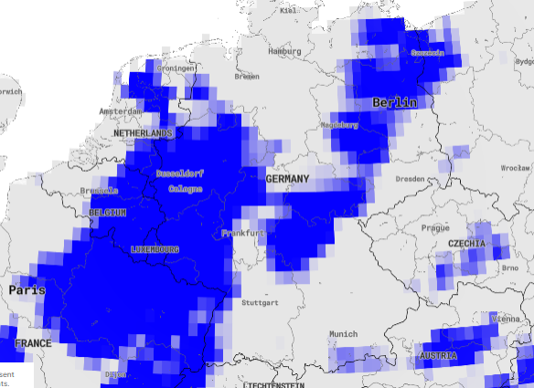

floods_germany_2021.png

### How to read the E3CI

- For every **month**, **place** and **component** (heat, cold, drought, rain, wind, hail, fire), the E3CI compares that month with the **same month in 1981–2010**: 0 = a normal month, 1 = one standard deviation above normal.
- **Values above 1 are extreme**, in three classes: 1–2, 2–3, above 3 (the darker the colour, the more extreme).
- Because every month is compared with itself, an extreme in winter or autumn means unusual *for that season*.

*Data: [E3CI – European Extreme Events Climate Index](https://www.climateindex.eu), from the Copernicus ERA5 reanalysis, monthly from January 1981 to September 2026, for 51 countries and ≈750 regions.*

## Europe

### Each hazard has its own story

[figure not shown]

Water extremes change less than heat. Since 2011 extreme precipitation has become about 1.5 times as frequent as in 1981–2010 (from 8% to 13% of the country-months), drought only slightly (from 13% to 15%), and the bars go up and down from year to year: wet and dry years alternate.

### When in the year?

[figure not shown]

Look at the drought and precipitation roses. Drought grows above all from April to August (in April, from 13% to 20% of the country-months), while extreme rain grows in winter and autumn: in January, February and October, from about one country-month in ten to one in six.

## Who is hit the hardest?

### One month, all countries

[figure not shown]

Spring droughts matter for crops and rivers. May 2011 and May 2026 were extreme in 25 of the 45 countries, more than any other May. The countries with the most extreme Mays since 1981 are in the west of central Europe: Belgium, Luxembourg, the Netherlands and Germany.

### Too dry and too wet, region by region

[figure not shown]

Each dot is a month above 2 in one of the 15 German regions. Severe drought months went from 20 in 1981–1990 to 137 in 2017–2026; severe rain months increased too, from 81 to 110. The same regions now swing between the two extremes.

### One map per year

[figure not shown]

Drought maps are patchier than heat maps: the large extreme Junes (1988, 2000, 2003, 2018, 2025 and 2026) are separated by years with almost no drought. In 2026, 21 of the 45 countries had an extreme June drought, the most in the series.

## Zoom in: Germany

### 46 years at a glance

[figure not shown]

One row per component, one cell per year. In Germany the drought row darkens in the same years as the heat row, such as 2003, 2018 and 2026: hot and dry summers come together. Since 2011, 21% of the months were in extreme drought, against 12% in 1981–2010.

### Month by month

[figure not shown]

Drought values stay lower than heat values: in Germany the E3CI for drought has never reached 3. The three most extreme months on record are May 2011, August 2018 and May 2025, two of them in late spring.

Records tell a different story from frequency. The last drought record in Germany dates back to May 2011: since then droughts have been more frequent, but none has been more intense. A changing climate does not always mean a new record every year.

### Which months, which years?

[figure not shown]

Before 2011 every calendar month was in extreme drought in at most one or two years out of ten. Since then May has been extreme in a third of the years and June in 40%: drought arrives when crops need water the most.

### A real event: the floods of July 2021

[figure not shown]

Too much water, in the middle of a dry decade. In July 2021 North Rhine-Westphalia reached 11.5, its most extreme month for rain since 1981. The ranking on the right shows a shared event: Luxembourg, Belgium, the Netherlands and Rhineland-Palatinate were hit in the same month.

### Region by region

[figure not shown]

Extreme July rain is a regional affair: in most Julys it hits only a few regions. July 2014 (11 regions) and July 2021 (10 regions) are the exceptions, with two thirds of Germany at once. Berlin and Brandenburg are the regions with the most extreme Julys since 1981.

*Data: E3CI – European Extreme Events Climate Index, https://www.climateindex.eu (IFAB; implemented by CMCC and Leithà – Unipol Group; distributed by Hypermeteo and Radarmeteo), based on Copernicus ERA5. Neither the European Commission nor ECMWF is responsible for any use of the Copernicus information. Colours: the E3CI Data Station palette (design by Cinzia Bongino). Country shapes: Natural Earth (public domain).*